# PSL Project 4: Movie Recommendation

Vijayakumar Sitha Mohan (VS24), Waitong Matthew Leung (wmleung2)

30-Nov-2020

## Introduction

We are provided with a dataset contains about 1 million anonymous ratings of approximately 3,900 movies made by 6,040 MovieLens users who joined MovieLens in 2000. The goal is to use the rating data to build a movie recommendation system based on a few different recommendation schemes, namely System I has two schemes based on movie genres, and System II has two schemes based on collaborative recommendation schemes.

System I is based on movie genres.

- One scheme recommend top 5 popular movies in each user selected genres. Popularity is measured by the number of ratings a movie receives. A popular movie may not be a highly rated movie.
- The other scheme recommend 5 random movies in each user selected genres.

System II is based on collaborative filtering recommendation.

- One scheme uses user-based collaborative filtering technique to estimate missing movie ratings based on other similar users ratings. Once missing movie ratings are estimated, movies with highest ratings is recommended at the top.
- The other scheme uses item-based collaborative filtering technique to estimate missing movie ratings based on other movies similar to the onces that rated highly by the user. The most similar one is recommended to the top.

```r
library(dplyr)
library(ggplot2)
library(recommenderlab)
library(DT)
library(data.table)
library(reshape2)
library(recommenderlab)
library(Matrix)
library(tidytable)
library(knitr)
```

## Download Data

Download the MovieLens 1M Dataset. There are four files:

- `README` [[Github_link](https://liangfgithub.github.io/MovieData/README?raw=true)]
- `movies.dat` [[Github_link](https://liangfgithub.github.io/MovieData/movies.dat?raw=true)]
- `ratings.dat` [[Github_link](https://liangfgithub.github.io/MovieData/ratings.dat?raw=true)]
- `users.dat` [[Github_link](https://liangfgithub.github.io/MovieData/users.dat?raw=true)]

```r
 myurl = "https://liangfgithub.github.io/MovieData/"
```

Check the readme file to understand the format of the other three files. You can also download them from the original site: https://grouplens.org/datasets/movielens/.

## Read in Data

### ratings data

```r
# use colClasses = 'NULL' to skip columns
ratings = read.csv(paste0(myurl, 'ratings.dat?raw=true'),
                   sep = ':',
                   colClasses = c('integer', 'NULL'),
                   header = FALSE)
colnames(ratings) = c('UserID', 'MovieID', 'Rating', 'Timestamp')

# TO DO: comment out the following line before submit. It is to limit the number of ratings item to speed up testing
ratings = ratings[1:100000,]
```

```r
write.csv(ratings,file="ratings.csv",quote=FALSE,row.names = FALSE)
```

|  | UserID | MovieID | Rating | Timestamp |
| --- | --- | --- | --- | --- |
| 1 | 1 | 1193 | 5 | 978300760 |
| 2 | 1 | 661 | 3 | 978302109 |
| 3 | 1 | 914 | 3 | 978301968 |
| 4 | 1 | 3408 | 4 | 978300275 |
| 5 | 1 | 2355 | 5 | 978824291 |
| 6 | 1 | 1197 | 3 | 978302268 |

### movies data

In movies.dat, some movie names contain single colon (:), so the method above does not work.

```r
movies = readLines(paste0(myurl, 'movies.dat?raw=true'))
movies = strsplit(movies, split = "::", fixed = TRUE, useBytes = TRUE)
movies = matrix(unlist(movies), ncol = 3, byrow = TRUE)
movies = data.frame(movies, stringsAsFactors = FALSE)
colnames(movies) = c('MovieID', 'Title', 'Genres')
movies$MovieID = as.integer(movies$MovieID)

# convert accented characters
movies$Title[73]
```

```
## [1] "Misérables, Les (1995)"
```

```r
movies$Title = iconv(movies$Title, "latin1", "UTF-8")
movies$Title[73]
```

```
## [1] "Misérables, Les (1995)"
```

```r
# extract year
movies$Year = as.numeric(unlist(
  lapply(movies$Title, function(x) substr(x, nchar(x)-4, nchar(x)-1))))
```

```r
write.csv(movies,file="movies.csv",quote=FALSE)
```

```r
# movies = movies['Genres'].str.get_dummies('|')
```

|  | MovieID | Title | Genres | Year |
| --- | --- | --- | --- | --- |
| 1 | 1 | Toy Story (1995) | Animation\|Children's\|Comedy | 1995 |
| 2 | 2 | Jumanji (1995) | Adventure\|Children's\|Fantasy | 1995 |
| 3 | 3 | Grumpier Old Men (1995) | Comedy\|Romance | 1995 |
| 4 | 4 | Waiting to Exhale (1995) | Comedy\|Drama | 1995 |
| 5 | 5 | Father of the Bride Part II (1995) | Comedy | 1995 |
| 6 | 6 | Heat (1995) | Action\|Crime\|Thriller | 1995 |

### user data

```r
users = read.csv(paste0(myurl, 'users.dat?raw=true'),
                 sep = ':', header = FALSE)
users = users[, -c(2,4,6,8)] # skip columns
colnames(users) = c('UserID', 'Gender', 'Age', 'Occupation', 'Zip-code')
```

|  | UserID | Gender | Age | Occupation | Zip-code |
| --- | --- | --- | --- | --- | --- |
| 1 | 1 | F | 1 | 10 | 48067 |
| 2 | 2 | M | 56 | 16 | 70072 |
| 3 | 3 | M | 25 | 15 | 55117 |
| 4 | 4 | M | 45 | 7 | 02460 |
| 5 | 5 | M | 25 | 20 | 55455 |
| 6 | 6 | F | 50 | 9 | 55117 |

For users, `Gender` is denoted by “M” for male and “F” for female, `Age` is chosen from the following ranges:

```
*  1:  "Under 18"
* 18:  "18-24"
* 25:  "25-34"
* 35:  "35-44"
* 45:  "45-49"
* 50:  "50-55"
* 56:  "56+"
```

and `Occupation` is chosen from the following choices:

```
*  0:  "other" or not specified
*  1:  "academic/educator"
*  2:  "artist"
*  3:  "clerical/admin"
*  4:  "college/grad student"
*  5:  "customer service"
*  6:  "doctor/health care"
*  7:  "executive/managerial"
*  8:  "farmer"
*  9:  "homemaker"
* 10:  "K-12 student"
* 11:  "lawyer"
* 12:  "programmer"
* 13:  "retired"
* 14:  "sales/marketing"
* 15:  "scientist"
* 16:  "self-employed"
* 17:  "technician/engineer"
* 18:  "tradesman/craftsman"
* 19:  "unemployed"
* 20:  "writer"
```

## Exploration

### Unique Users?

UserID ranges from 1 to 6040.

```r
dim(users)
```

```
## [1] 6040    5
```

```r
length(unique(ratings$UserID))
```

```
## [1] 669
```

### Unique Movies?

```r
dim(movies)
```

```
## [1] 3883    4
```

```r
length(unique(ratings$MovieID))
```

```
## [1] 3264
```

```r
movies_not_rated = movies %>%
  filter(!(MovieID %in% ratings$MovieID))
dim(movies_not_rated)
```

```
## [1] 619   4
```

### Dist of Ratings

Most of the ratings are in the 3-5 range.

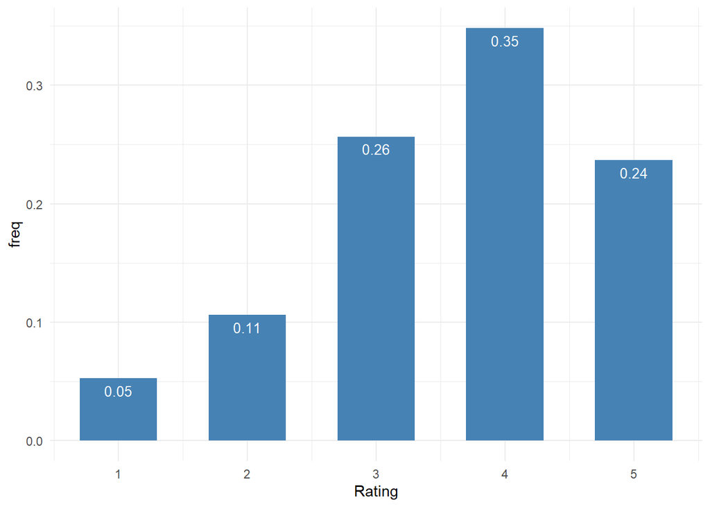

```r
tmp = data.frame(Rating = 1:5,
                 freq = as.vector(table(ratings$Rating)/nrow(ratings)))
ggplot(data = tmp, aes(x = Rating, y = freq)) +
  geom_bar(stat="identity", fill = 'steelblue', width = 0.6) +
  geom_text(aes(label=round(freq, dig=2)),
                vjust=1.6, color="white", size=3.5) +
  theme_minimal()
```

### Ratings per User

```r
tmp = ratings %>%
  group_by(UserID) %>%
  summarize(ratings_per_user = n())
summary(tmp$ratings_per_user)
```

```
##    Min. 1st Qu.  Median    Mean 3rd Qu.    Max.
##    13.0    43.0    87.0   149.5   182.0  1226.0
```

```r
stem(tmp$ratings_per_user)
```

```
##
##   The decimal point is 2 digit(s) to the right of the |
##
##    0 | 12222222222222222222222222222222222222222222222222222223333333333333+270
##    1 | 00000000000000000000000000000011111111111111111111111111111222222222+83
##    2 | 0000000000111111112222233333333444444444555556666666777788899999
##    3 | 0000000011112222555566778888999
##    4 | 000011222333344557788889
##    5 | 01111335668899
##    6 | 00124778
##    7 | 0226699
##    8 | 2377
##    9 | 7
##   10 | 2
##   11 | 5
##   12 | 3
```

```r
sum(tmp$ratings_per_user > 500)
```

```
## [1] 36
```

```r
sort(tmp$ratings_per_user[tmp$ratings_per_user>1300])
```

```
## integer(0)
```

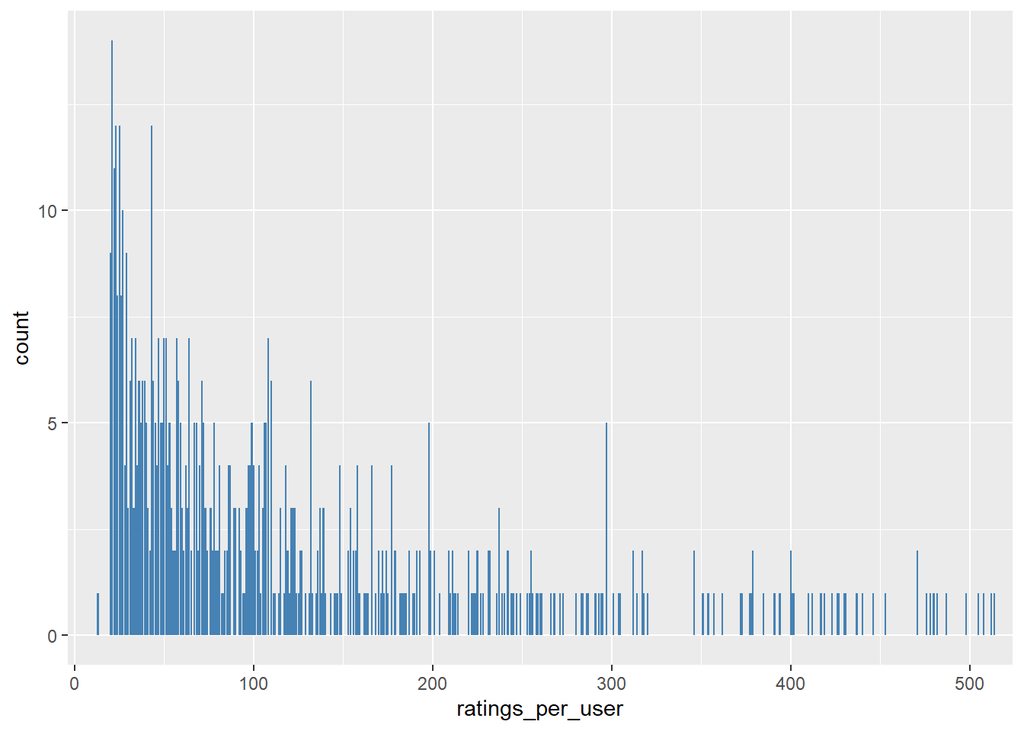

```r
tmp %>%
  ggplot(aes(ratings_per_user)) +
  geom_bar(fill = "steelblue") + coord_cartesian(c(20, 500))
```

Combining `users` and `tmp`, you could further explore how `ratings_per_user` depends on Gender, Age, and Occupation of users.

```r
tmp = tmp %>% full_join(users, by = 'UserID')
```

### Ratings per Movie

```r
tmp = ratings %>%
  group_by(MovieID) %>%
  summarize(ratings_per_movie = n(), ave_ratings = mean(Rating)) %>%
  inner_join(movies, by = 'MovieID')
summary(tmp$ratings_per_movie)
```

```
##    Min. 1st Qu.  Median    Mean 3rd Qu.    Max.
##    1.00    5.00   15.00   30.64   40.00  406.00
```

```r
tmp %>%
  filter(ratings_per_movie > 2000) %>%
  arrange(desc = ratings_per_movie) %>%
  select(c("Title", "ratings_per_movie")) %>%
  print(n = 31)
```

```
## # A tibble: 0 x 2
## # ... with 2 variables: Title <chr>, ratings_per_movie <int>
```

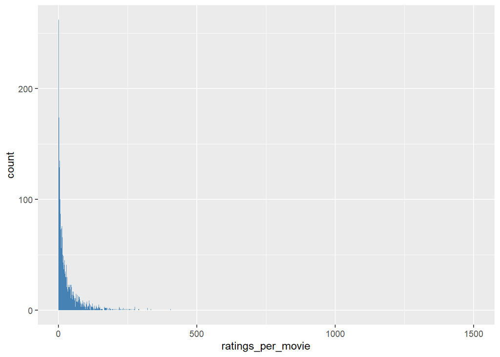

```r
tmp %>% ggplot(aes(ratings_per_movie)) +
  geom_bar(fill = "steelblue", width = 1) + coord_cartesian(c(1,1500))
```

```r
small_image_url = "https://liangfgithub.github.io/MovieImages/"
ratings %>%
  group_by(MovieID) %>%
  summarize(ratings_per_movie = n(),
            ave_ratings = round(mean(Rating), dig=3)) %>%
  inner_join(movies, by = 'MovieID') %>%
  filter(ratings_per_movie > 1000) %>%
  top_n(10, ave_ratings) %>%
  mutate(Image = paste0('<img src="',
                        small_image_url,
                        MovieID,
                        '.jpg?raw=true"></img>')) %>%
  select('Image', 'Title', 'ave_ratings') %>%
  arrange(desc(-ave_ratings)) %>%
  datatable(class = "nowrap hover row-border",
            escape = FALSE,
            options = list(dom = 't',
                          scrollX = TRUE, autoWidth = TRUE))
```

|  | Image | Title | ave_ratings |
| --- | --- | --- | --- |

### Dist of Genres

First create a binary indicator for the 18 genres for each movie.

```r
genres = as.data.frame(movies$Genres, stringsAsFactors=FALSE)
tmp = as.data.frame(tstrsplit(genres[,1], '[|]',
                              type.convert=TRUE),
                    stringsAsFactors=FALSE)
genre_list = c("Action", "Adventure", "Animation",
               "Children's", "Comedy", "Crime",
               "Documentary", "Drama", "Fantasy",
               "Film-Noir", "Horror", "Musical",
               "Mystery", "Romance", "Sci-Fi",
               "Thriller", "War", "Western")
m = length(genre_list)
genre_matrix = matrix(0, nrow(movies), length(genre_list))
for(i in 1:nrow(tmp)){
  genre_matrix[i,genre_list %in% tmp[i,]]=1
}
colnames(genre_matrix) = genre_list
remove("tmp", "genres")
```

Then we can output histograms of the 18 genres based on `movies` or based on `ratings`.

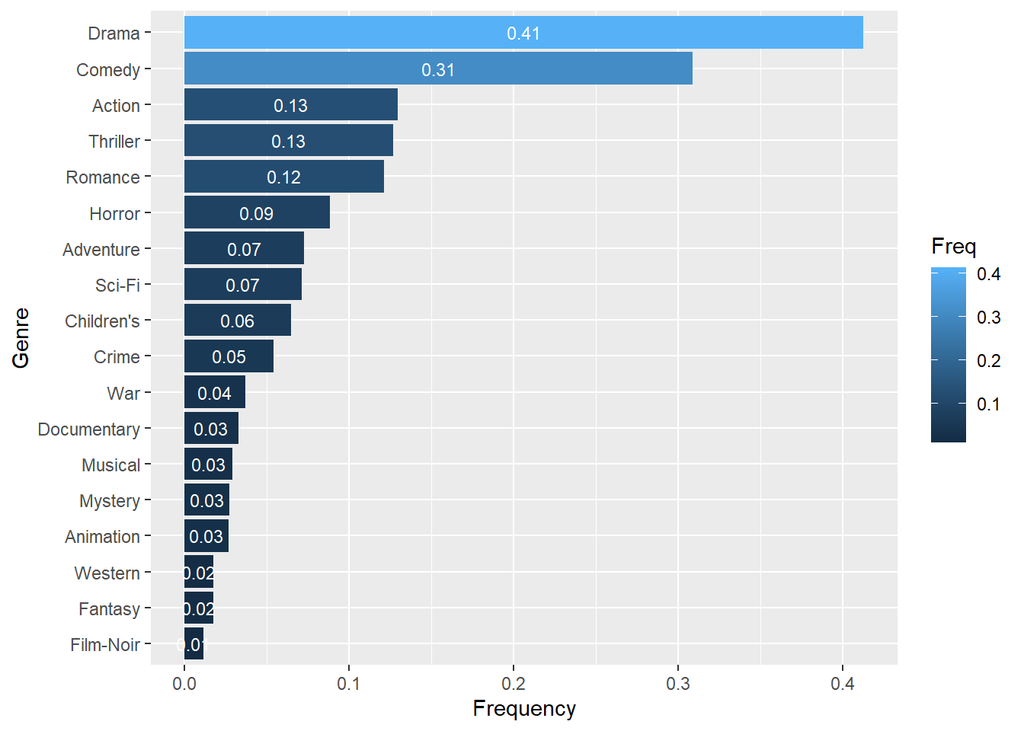

```r
data.frame(Genres = genre_list,
                 Freq = as.vector(colMeans(genre_matrix))) %>%
  ggplot(aes(reorder(Genres, Freq), Freq, fill = Freq)) +
  geom_bar(stat = "identity") +
    geom_text(aes(label = round(Freq, dig=2)),
            position = position_stack(vjust = 0.5),
            color="white", size=3) +
  coord_flip() +
  scale_colour_brewer(palette="Set1") +
  labs(y = 'Frequency', x = 'Genre')
```

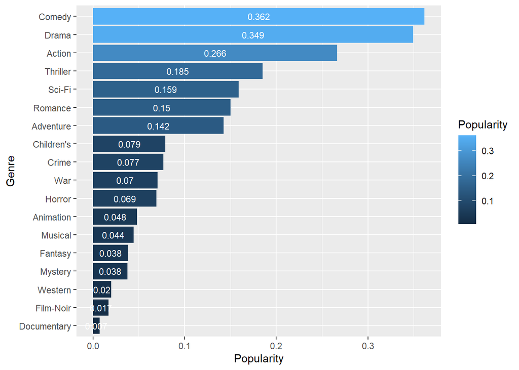

```r
tmp = ratings %>%
  left_join(data.frame(MovieID = movies$MovieID, genre_matrix),
            by = "MovieID") %>%
  select(-c("UserID", "MovieID", "Rating", "Timestamp"))

data.frame(Genres = genre_list,
                 Popularity = as.vector(colMeans(tmp))) %>%
  ggplot(aes(reorder(Genres, Popularity), Popularity, fill = Popularity)) +
  geom_bar(stat = "identity") +
  geom_text(aes(label = round(Popularity, dig=3)),
            position = position_stack(vjust = 0.5),
            color="white", size=3) +
  coord_flip() +
  labs(y = 'Popularity', x = 'Genre')
```

```r
tmp = colSums(genre_matrix)
summary(tmp)
```

```
##    Min. 1st Qu.  Median    Mean 3rd Qu.    Max.
##      44     108     231     356     439    1603
```

```r
movies[which(tmp==6), ]
```

```
## [1] MovieID Title   Genres  Year
## <0 rows> (or 0-length row.names)
```

```r
movies[which(tmp==5), ]
```

```
## [1] MovieID Title   Genres  Year
## <0 rows> (or 0-length row.names)
```

```r
# range(movies$Year) % 1919 to 2000
tmp = data.frame(Year = movies$Year, genre_matrix) %>%
  group_by(Year) %>%
  summarise_all(sum)
tmp[,-1] = apply(tmp[, -1], 2, cumsum)
tmp[,-1] = tmp[,-1]/sum(tmp[nrow(tmp), -1])
print(round(tmp[nrow(tmp),-1], dig=3))
```

```
## # A tibble: 1 x 18
##   Action Adventure Animation Children.s Comedy Crime Documentary Drama Fantasy
##    <dbl>     <dbl>     <dbl>      <dbl>  <dbl> <dbl>       <dbl> <dbl>   <dbl>
## 1  0.078     0.044     0.016      0.039  0.187 0.033        0.02  0.25   0.011
## # ... with 9 more variables: Film.Noir <dbl>, Horror <dbl>, Musical <dbl>,
## #   Mystery <dbl>, Romance <dbl>, Sci.Fi <dbl>, Thriller <dbl>, War <dbl>,
## #   Western <dbl>
```

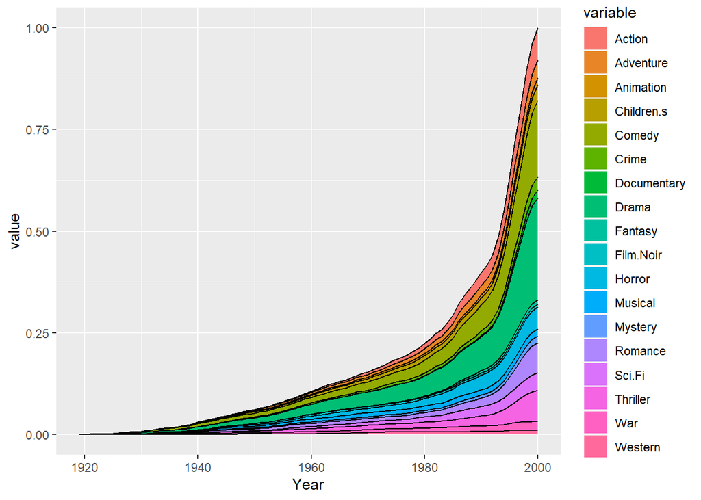

```r
tmp = reshape2::melt(tmp, id.vars="Year")
tmp %>%
  ggplot(aes(Year, value, group = variable)) +
  geom_area(aes(fill = variable)) +
  geom_line(aes(group = variable), position = "stack")
```

```r
ratings$Timestamp = NULL
```

## Train and Test Split

Create

- train data that contain about 80% rows of ratings.dat
- test data that contain about 20% of rows of ratings.dat

```r
set.seed(100)
train.id = sample(nrow(ratings), floor(nrow(ratings)) * 0.8)
train = ratings[train.id, ]
head(train)
```

```
##       UserID MovieID Rating
## 82423    547    2716      5
## 69232    463    2379      1
## 31705    216    3011      3
## 89806    591     848      4
## 76695    520    3893      4
## 91652    608    3301      4
```

```r
test = ratings[-train.id, ]
head(test)
```

```
##    UserID MovieID Rating
## 11      1     595      5
## 12      1     938      4
## 50      1     531      4
## 57      2     647      3
## 59      2     648      4
## 63      2    2916      3
```

## Recommender System

### First create a Utility matrix stroed as a Sparse matrix

```r
i = paste0('u', train$UserID)
j = paste0('m', train$MovieID)
x = train$Rating
tmp = data.frame(i, j, x, stringsAsFactors = T)
Rmat = sparseMatrix(as.integer(tmp$i), as.integer(tmp$j), x = tmp$x)
rownames(Rmat) = levels(tmp$i)
colnames(Rmat) = levels(tmp$j)
Rmat = new('realRatingMatrix', data = Rmat)
```

```r
range(train$MovieID)
```

```
## [1]    1 3952
```

```r
length(unique(train$MovieID))
```

```
## [1] 3194
```

```r
range(train$UserID)
```

```
## [1]   1 669
```

```r
length(unique(train$UserID))
```

```
## [1] 669
```

```r
dim(Rmat)
```

```
## [1]  669 3194
```

### System Ia - Genre based (Average Popular Rating)

```r
rec_POPULAR = Recommender(Rmat, method = 'POPULAR',
                          parameter = list(normalize = 'center'))

#Summary of model parameters
rec_POPULAR@model
```

```
## $topN
## Recommendations as 'topNList' with n = 3194 for 1 users.
##
## $ratings
## 1 x 3194 rating matrix of class 'realRatingMatrix' with 3194 ratings.
## Normalized using center on rows.
##
## $normalize
## [1] "center"
##
## $aggregationRatings
## standardGeneric for "colMeans" defined from package "base"
##
## function (x, na.rm = FALSE, dims = 1, ...)
## standardGeneric("colMeans")
## <bytecode: 0x00000000329bdbf8>
## <environment: 0x0000000013dfc7c8>
## Methods may be defined for arguments: x
## Use  showMethods("colMeans")  for currently available ones.
##
## $aggregationPopularity
## standardGeneric for "colSums" defined from package "base"
##
## function (x, na.rm = FALSE, dims = 1, ...)
## standardGeneric("colSums")
## <bytecode: 0x00000000329bf728>
## <environment: 0x0000000013e8ecc8>
## Methods may be defined for arguments: x
## Use  showMethods("colSums")  for currently available ones.
##
## $verbose
## [1] FALSE
```

```r
# predict ratings for all users, and compare it to first three users
start.time = Sys.time()
POPULAR_recom = predict(rec_POPULAR,
                Rmat, type = 'ratingMatrix')
recom_mat <- as(Rmat, "matrix")
AVG_POPULAR_recom = colMeans(recom_mat,na.rm=TRUE)
POPULAR_time = Sys.time() - start.time
```

We display the predicted average popular ratings for every users, and original rating of the first 10 movies for the three users.

```r
AVG_POPULAR_recom[1:10]
```

```
##       m1      m10     m100    m1000    m1002    m1003    m1004    m1005
## 4.162921 3.697368 3.200000 5.000000 5.000000 3.142857 2.571429 2.066667
##    m1006    m1007
## 2.000000 3.000000
```

```r
as(Rmat, 'matrix')[1:3, 1:10]
```

```
##      m1 m10 m100 m1000 m1002 m1003 m1004 m1005 m1006 m1007
## u1    5  NA   NA    NA    NA    NA    NA    NA    NA    NA
## u10   5  NA   NA    NA    NA    NA    NA    NA    NA    NA
## u100 NA  NA   NA    NA    NA    NA    NA    NA    NA    NA
```

- Evaluation with RMSE

We replace any NA predicted rating with weighted average of original user rating distribution of 3.61.

```r
POPULAR_test.pred = test
POPULAR_test.pred$rating = NA
```

```r
# For all lines in test file, one by one
for (u in 1:nrow(test)){

    # Read userid and movieid from columns 2 and 3 of test data
    movieid = paste("m",as.character(test$MovieID[u]), sep ="" )

    # handle missing values; replace with weighted average of original user rating distribution of 3.61
    POPULAR_test.pred$rating[u] = ifelse(movieid %in% names(AVG_POPULAR_recom), AVG_POPULAR_recom[[movieid]], 3.61)
}

# Calculate RMSE
POPULAR_RMSE = sqrt(mean((test$Rating - POPULAR_test.pred$rating)^2))
```

### System Ib - Genre based (Hybrid)

- Train a genre based recommender system with hybrid model using R package [recommenderlab]. The model mix with POPULAR movie (most reviewed), RANDOM for serendipity and RERECOMMEND for the user his/her own rating with weighting of 0.6, 0.2 and 0.2 respectively.

```r
# mix popular movies with a random recommendations for diversity and rerecommend some movies the user liked.
rec_HYBRID = HybridRecommender(
  Recommender(Rmat, method = "POPULAR"),
  Recommender(Rmat, method = "RANDOM"),
  Recommender(Rmat, method = "RERECOMMEND"),
  weights = c(.6, .2, .2)
)


#Summary of model parameters
rec_HYBRID@model
```

```
## $recommenders
## $recommenders[[1]]
## Recommender of type 'POPULAR' for 'realRatingMatrix'
## learned using 669 users.
##
## $recommenders[[2]]
## Recommender of type 'RANDOM' for 'realRatingMatrix'
## learned using 669 users.
##
## $recommenders[[3]]
## Recommender of type 'RERECOMMEND' for 'realRatingMatrix'
## learned using 669 users.
##
##
## $weights
## [1] 0.6 0.2 0.2
```

- Make prediction on the test data

First let’s predict all un-rated movies for the first three users in the training data. No information for users not in the training data; the coldstart issue.

```r
# predict ratings for the first three users
HYBRID_recom = predict(rec_HYBRID,
                Rmat[1:3], type = 'ratings')
```

We display the original and predicted ratings of the first 10 movies for the three users. Note that the final prediction could still have missing values.

```r
as(HYBRID_recom, 'matrix')[, 1:10]
```

```
##            m1      m10     m100    m1000    m1002    m1003    m1004    m1005
## u1         NA 4.479410 3.806949 5.333137 4.861435 3.838184 3.510206 3.171028
## u10        NA 4.421051 3.875985 5.397475 4.347126 3.925693 3.370197 3.079301
## u100 3.335048 3.003275 2.431497 4.512348 4.150477 2.678588 2.260834 2.149821
##         m1006    m1007
## u1   2.853477 3.663169
## u10  2.785354 3.844013
## u100 1.758786 2.653066
```

```r
as(Rmat, 'matrix')[1:3, 1:10]
```

```
##      m1 m10 m100 m1000 m1002 m1003 m1004 m1005 m1006 m1007
## u1    5  NA   NA    NA    NA    NA    NA    NA    NA    NA
## u10   5  NA   NA    NA    NA    NA    NA    NA    NA    NA
## u100 NA  NA   NA    NA    NA    NA    NA    NA    NA    NA
```

- Evaluation with RMSE

We replace any NA predicted rating with weighted average of original user rating distribution of 3.61.

```r
# This may take a long time
start.time = Sys.time()
HYBRID_recom = predict(rec_HYBRID,
                Rmat, type = 'ratings')
HYBRID_rec_list = as(HYBRID_recom, 'list')  # each element are ratings of that user

HYBRID_test.pred = test
HYBRID_test.pred$rating = NA

HYBRID_time = Sys.time() - start.time
```

```r
# For all lines in test file, one by one
for (u in 1:nrow(test)){

    # Read userid and movieid from columns 2 and 3 of test data
    userid = as.integer(test$UserID[u])
    movieid = as.integer(test$MovieID[u])

    rating = HYBRID_rec_list[[userid]][movieid]
    # handle missing values; replace with weighted average of original user rating distribution of 3.61
    HYBRID_test.pred$rating[u] = ifelse(is.na(rating), 3.61, rating)
}

# Calculate RMSE
HYBRID_RMSE = sqrt(mean((test$Rating - HYBRID_test.pred$rating)^2))
HYBRID_RMSE
```

```
## [1] 1.286223
```

### System IIa - User-Based Collaborative Filtering

Train a user-based collaborative filtering (UBCF) recommender system using R package [recommenderlab].

We use the following parameters for the UBCF model:

```r
rec_UBCF = Recommender(Rmat, method = 'UBCF',
                  parameter = list(normalize = 'Z-score',
                                   method = 'Cosine',
                                   nn = 25))
#Summary of model parameters
rec_UBCF@model
```

```
## $description
## [1] "UBCF-Real data: contains full or sample of data set"
##
## $data
## 669 x 3194 rating matrix of class 'realRatingMatrix' with 80000 ratings.
## Normalized using z-score on rows.
##
## $method
## [1] "Cosine"
##
## $nn
## [1] 25
##
## $sample
## [1] FALSE
##
## $weighted
## [1] TRUE
##
## $normalize
## [1] "Z-score"
##
## $min_matching_items
## [1] 0
##
## $min_predictive_items
## [1] 0
##
## $verbose
## [1] FALSE
```

- Make prediction on the test data

First let’s predict all un-rated movies for the first three users in the training data. No information for users not in the training data; the coldstart issue.

```r
# predict ratings for the first three users
UBCF_recom = predict(rec_UBCF,
                Rmat[1:3], type = 'ratings')
```

We display the original and predicted ratings of the first 10 movies for the three users. Note that the final prediction could still have missing values.

```r
as(UBCF_recom, 'matrix')[, 1:10]
```

```
##            m1      m10 m100 m1000 m1002 m1003 m1004    m1005 m1006 m1007
## u1         NA       NA   NA    NA    NA    NA    NA       NA    NA    NA
## u10        NA 3.989260   NA    NA    NA    NA    NA 2.894163    NA    NA
## u100 3.373913 2.635406   NA    NA    NA    NA    NA       NA    NA    NA
```

```r
as(Rmat, 'matrix')[1:3, 1:10]
```

```
##      m1 m10 m100 m1000 m1002 m1003 m1004 m1005 m1006 m1007
## u1    5  NA   NA    NA    NA    NA    NA    NA    NA    NA
## u10   5  NA   NA    NA    NA    NA    NA    NA    NA    NA
## u100 NA  NA   NA    NA    NA    NA    NA    NA    NA    NA
```

- Evaluation with RMSE

We replace any NA predicted rating with weighted average of original user rating distribution of 3.61.

```r
# This may take a long time
start.time = Sys.time()
UBCF_recom = predict(rec_UBCF,
                Rmat, type = 'ratings')
UBCF_rec_list = as(UBCF_recom, 'list')  # each element are ratings of that user

UBCF_test.pred = test
UBCF_test.pred$rating = NA

UBCF_time = Sys.time() - start.time
```

```r
# For all lines in test file, one by one
for (u in 1:nrow(test)){

    # Read userid and movieid from columns 2 and 3 of test data
    userid = as.integer(test$UserID[u])
    movieid = as.integer(test$MovieID[u])

    rating = UBCF_rec_list[[userid]][movieid]
    # handle missing values; replace with weighted average of original user rating distribution of 3.61
    UBCF_test.pred$rating[u] = ifelse(is.na(rating), 3.61, rating)
}

# Calculate RMSE
UBCF_RMSE = sqrt(mean((test$Rating - UBCF_test.pred$rating)^2))
UBCF_RMSE
```

```
## [1] 1.189769
```

```r
# recommenderRegistry$get_entry_names()
```

### System IIb - Item-based Collaborative Filtering

Train Item-based collaborative filtering (IBCF) recommender system using R package recommenderLab

We use the following parameters for the IBCF model:

- Z-score normalization to the ratings matrix
- similarity measure is cosine similarity
- similarity matrix is not normalized

```r
rec_IBCF = Recommender(Rmat, method = 'IBCF',
                  parameter = list(normalize = 'Z-score',
                                   method = 'Cosine'))


#Summary of model parameters
rec_IBCF@model$method
```

```
## [1] "Cosine"
```

```r
rec_IBCF@model$normalize
```

```
## [1] "Z-score"
```

```r
rec_IBCF@model$normalize_sim_matrix
```

```
## [1] FALSE
```

```r
model_details <- getModel(rec_IBCF)
model_details$description
```

```
## [1] "IBCF: Reduced similarity matrix"
```

```r
n_items_top = 20
#image(model_details$sim[1:n_items_top, 1:n_items_top], main = "Heatmap of the first rows and columns")
```

- Make prediction on the test data

First we predict the top 5 recommended movie for the first user.

```r
recc_predicted <- predict(object = rec_IBCF, newdata = Rmat[1:100], n = 5)
recc_predicted
```

```
## Recommendations as 'topNList' with n = 5 for 100 users.
```

```r
class(recc_predicted)
```

```
## [1] "topNList"
## attr(,"package")
## [1] "recommenderlab"
```

```r
slotNames(recc_predicted)
```

```
## [1] "items"      "ratings"    "itemLabels" "n"
```

```r
recc_predicted@items[[1]]
```

```
## [1]  22  69  72 129 133
```

This is the predicted titles.

```r
recc_user_1 <- recc_predicted@items[[1]]
movies_user_1 <- recc_predicted@itemLabels[recc_user_1]
movies[movies$MovieID %in% recc_user_1,]$Title
```

```
## [1] "Copycat (1995)"               "Friday (1995)"
## [3] "Kicking and Screaming (1995)" "Pie in the Sky (1995)"
## [5] "Nueba Yol (1995)"
```

```r
recc_matrix <- sapply(recc_predicted@items, function(x){
  movies[movies$MovieID == x,]


})
dim(recc_matrix)
```

```
## [1]   4 100
```

```r
recc_matrix[, 1:4]
```

```
##         u1          u10         u100        u101
## MovieID Integer,0   Integer,0   Integer,0   Integer,2
## Title   Character,0 Character,0 Character,0 Character,2
## Genres  Character,0 Character,0 Character,0 Character,2
## Year    Numeric,0   Numeric,0   Numeric,0   Numeric,2
```

- Evaluation with RMSE

We replace any NA predicted rating with weighted average of original user rating distribution of 3.61.

```r
# This may take a long time
start.time = Sys.time()
IBCF_recom = predict(rec_IBCF,
                Rmat, type = 'ratings')
IBCF_rec_list = as(IBCF_recom, 'list')  # each element are ratings of that user

IBCF_test.pred = test
IBCF_test.pred$rating = NA

IBCF_time = Sys.time() - start.time
```

```r
# For all lines in test file, one by one
for (u in 1:nrow(test)){

    # Read userid and movieid from columns 2 and 3 of test data
    userid = as.integer(test$UserID[u])
    movieid = as.integer(test$MovieID[u])

    rating = IBCF_rec_list[[userid]][movieid]
    # handle missing values; replace with weighted average of original user rating distribution of 3.61
    IBCF_test.pred$rating[u] = ifelse(is.na(rating), 3.61, rating)
}

# Calculate RMSE
IBCF_RMSE = sqrt(mean((test$Rating - IBCF_test.pred$rating)^2))
IBCF_RMSE
```

```
## [1] 1.244003
```

## Summary

Since one full run takes about 1 hour on a MSI Intel i7 16G memory laptop on the full dataset of ratings, we speed up the processing of this markdown document by running a reduced dataset (10% of full dataset) evaluation only once in this file.

We added another markdown file: Parallel.RMD which evaluates each model 10 iterations on full dataset using parallel and foreach package to speed up the process.

From the following table of prediction speed and lowest RMSE on both reduced dataset and full dataset, System I Average Popular model stands out.

### Reduced dataset (10% of full - dataset 100000 ratings)

1 iteration RMSE Comparison of different System and scheme for reduced dataset:

| System.I..Avg.Popular | System.I..Hybrid | System.II..UBCF | System.II..IBCF |
| --- | --- | --- | --- |
| 0.9989168 | 1.286223 | 1.189769 | 1.244003 |

1 iteration prediction running time Comparison of different System and scheme for reduced dataset:

| System.I..Avg.Popular | System.I..Hybrid | System.II..UBCF | System.II..IBCF |
| --- | --- | --- | --- |
| 0.6788628 secs | 21.39305 secs | 11.91006 secs | 0.7590208 secs |

### Result (Full dataset - 1 million ratings)

10 iterations of RMSE for the full dataset:

| Iterations | SystemI_Avg_Popular | SystemI_Hybrid | SystemII_UBCF | SystemII_IBCF |
| --- | --- | --- | --- | --- |
| 1 | 0.9777898 | 1.282696 | 1.194054 | 1.192984 |
| 2 | 0.9786383 | 1.281837 | 1.198203 | 1.199445 |
| 3 | 0.9817414 | 1.279632 | 1.195565 | 1.195434 |
| 4 | 0.9791549 | 1.284619 | 1.199106 | 1.198175 |
| 5 | 0.9799435 | 1.282067 | 1.199787 | 1.199285 |
| 6 | 0.9797640 | 1.287806 | 1.198254 | 1.196161 |
| 7 | 0.9804747 | 1.282609 | 1.198958 | 1.193747 |
| 8 | 0.9773050 | 1.281420 | 1.197127 | 1.198663 |
| 9 | 0.9815513 | 1.281839 | 1.202666 | 1.197704 |
| 10 | 0.9766996 | 1.283252 | 1.199742 | 1.198781 |

Average RMSE of the 10 iterations of full dataset:

| SystemI_Avg_Popular | SystemI_Hybrid | SystemII_UBCF | SystemII_IBCF |
| --- | --- | --- | --- |
| 0.9793063 | 1.282778 | 1.198346 | 1.197038 |

Running time of 10 iterations using parallel and foreach package for full dataset:

| SystemI_Avg_Popular | SystemI_Hybrid | SystemII_UBCF | SystemII_IBCF |
| --- | --- | --- | --- |
| 334.793 secs (~6min) | 13856.588 secs (~4hrs) | 6924.217 secs (~2hrs) | 798.802 secs (~13min) |